# Session 0: Setup and R/RStudio

**Interactive mode:** click a code block or *Show Plot* button to reveal/hide its corresponding plot.

# Learning goals

By the end of this session you will be able to:

1. Describe what **R** and **RStudio** are and how they work together.
2. Create and knit an **R Markdown** report for reproducible research.
3. Write and run basic R commands.
4. Install, load, and briefly use external packages through the **library** system.

# What are R and RStudio?

R is a free, open-source programming language for statistical computing, data analysis, and visualization.

On its own, R can be run from a command-line interface. However, most users prefer to use **RStudio** (now called Posit), which is an Integrated Development Environment (IDE). RStudio provides a graphical interface with multiple panes:

- **Source pane** (top-left): where you write and edit scripts or R Markdown files.
- **Console pane** (bottom-left): where R commands are executed immediately.
- **Environment/History pane** (top-right): shows active objects in memory and your command history.
- **Files/Plots/Packages/Help pane** (bottom-right): for browsing files, viewing plots, managing packages, and accessing documentation.

**Key idea:** R is the engine that does the computation; RStudio is the dashboard that makes it easier to drive.

**Exercise:** Open RStudio on your computer and identify what each pane currently displays.

# What is R Markdown?

**R Markdown (RMD)** is a format that lets you combine text, code, and results in one reproducible document. It is powerful for writing assignments, reports, and research papers because the results are always linked to the underlying code.

- **Markdown** provides the formatting (headings, bold, lists, links).
- **R code chunks** allow you to run R code directly inside the document.
- **Knitting** compiles the text and code into a report (HTML, PDF, or Word).

**Steps to create your first RMD:** 1. Go to `File` → `New File` → `R Markdown…`. 2. Give the file a title and author name, then click **OK**. 3. Try knitting the default file to see how R Markdown works.

# Markdown basics

Some useful syntax for writing: - Headings: `#` (level 1), `##` (level 2), `###` (level 3) - Bold and italic: `**bold**`, `*italic*` - Lists: `- item` or `1. item` - Inline code: `` `code` `` - Hyperlinks: `[RStudio website](https://posit.co)`

# Your first code chunks

Chunks are sections of R code in R Markdown. They start with three backticks and `{r}`, and end with three backticks.

```r
# A simple example
print("Hello, world! This is R.")
```

```
## [1] "Hello, world! This is R."
```

You can run chunks by clicking the green triangle next to them, or run lines directly in the Console.

# Basic R syntax and objects

## Assigning objects

Use `<-` to assign values to objects. This makes your code clearer and is preferred over `=` in most situations.

```r
x <- 10
y <- 4
z <- x + y
z
```

```
## [1] 14
```

## Vectors

Vectors hold multiple values of the same type.

```r
numbers <- c(1, 2, 3, 4, 5)
names <- c("Alice", "Bob", "Charlie")
mean(numbers)
```

```
## [1] 3
```

```r
numbers * 2
```

```
## [1]  2  4  6  8 10
```

## Data frames

Data frames are like spreadsheets: rows are observations, columns are variables.

```r
students <- data.frame(
  name = c("Alice", "Bob", "Charlie"),
  age = c(20, 22, 21),
  passed = c(TRUE, TRUE, FALSE)
)
summary(students)
```

```
##      name                age         passed
##  Length:3           Min.   :20.0   Mode :logical
##  Class :character   1st Qu.:20.5   FALSE:1
##  Mode  :character   Median :21.0   TRUE :2
##                     Mean   :21.0
##                     3rd Qu.:21.5
##                     Max.   :22.0
```

# Installing and loading packages

Packages extend the functionality of R. To use them, you must first **install** them once, and then **load** them each time you start a new R session.

## Installing packages

Installation requires internet access. For example, to install the package **tidyverse**:

```r
if (FALSE) install.packages("tidyverse")
```

## Loading libraries

After installation, load the package into your current session:

```r
library(tidyverse)
```

If you forget to load the package, R will give an error like `could not find function`. Always make sure to load packages at the top of your script or R Markdown.

## Example with tidyverse

```r
# Load tidyverse and try a simple task
library(tidyverse)
my_data <- tibble(
  group = rep(c("A", "B"), each = 3),
  value = c(2, 4, 6, 1, 3, 5)
)
my_data |> group_by(group) |> summarize(avg_value = mean(value))
```

| group | avg_value |
| --- | --- |
| A | 4 |
| B | 3 |

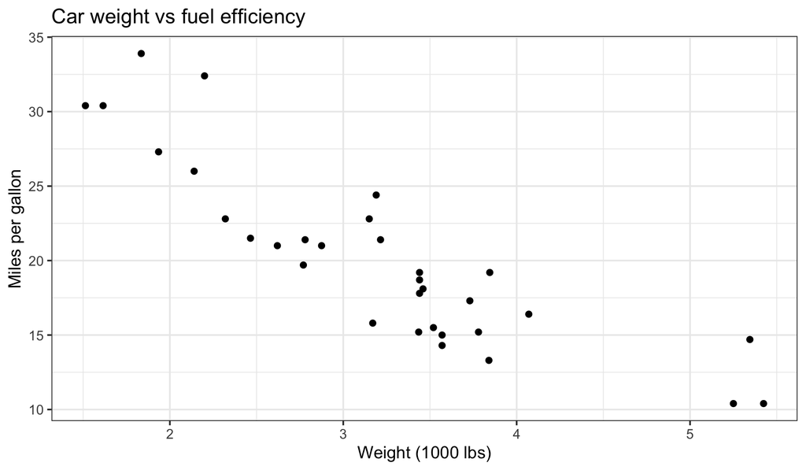

```r
# Simple plot with ggplot2
mtcars |> ggplot(aes(x = wt, y = mpg)) +
  geom_point() +
  labs(title = "Car weight vs fuel efficiency",
       x = "Weight (1000 lbs)",
       y = "Miles per gallon")+theme_bw()
```

**Tip:** Use `installed.packages()` to see what is already installed, and `update.packages()` to keep them up to date.